# Validation of Analytic GRIM-U: a hypothesis-testing simulation

Ian Hussey

today

# Introduction

This introduction is structured following the ADEMP framework (Aims, Data-generating process, Estimands, Methods, Performance) as described by Morris, White, and Crowther (2019) and operationalised for psychology by Siepe et al. (2024).

## Project description

GRIM-U (Grimes, 2024) is a forensic consistency check for reported Mann–Whitney *U*-test results: given a reported pair of sample sizes ($n_1$, $n_2$) and a reported *p*-value rounded to a given number of decimal places, it asks whether *any* attainable *U* statistic (integer or half-integer, with or without ties) produces a *p*-value that rounds to the reported value. If no attainable *U* does so, the report is flagged as mathematically inconsistent.

`{analyticgrimu}` (Hussey, 2025) is an R package that re-implements GRIM-U analytically rather than by Monte Carlo simulation over random rank assignments. Because the package enumerates the exact distribution of attainable *U* values and the corresponding *p*-values under the three common conventions (R’s exact `pwilcox`, R’s continuity-corrected asymptotic, and SPSS’s uncorrected asymptotic), it returns a deterministic verdict for any (`n1`, `n2`, `p_reported`, `digits`) input. The motivating empirical application is forensic re-analysis of published Mann–Whitney results in small-sample experimental studies, where the test is most common and where its discrete *p*-value space is at its most informative.

This simulation study evaluates the operating characteristics of `grimu_check()` as the per-condition sample size and the population effect size are varied. It is the methodological counterpart to the unit tests in the package: unit tests confirm that the function returns the expected verdict on a handful of hand-picked cases; this simulation confirms that, across thousands of randomly generated *U*-tests, the function behaves as advertised.

## Prior related work

Grimes (2024) introduced the GRIM-U idea and provided a Monte Carlo prototype in R. The development history of `{analyticgrimu}` (see `analytic_grimu.Rmd` in this directory) documents bug fixes to that prototype (notably the use of `round()` rather than `ceiling()` for half-integer *U* targets) and the refactor from Monte Carlo to analytic enumeration. Those documents establish correctness of the implementation against the original prototype on a fixed grid of inputs; they do not characterise its long-run operating characteristics. No prior preregistered simulation has been conducted by the contributors on this specific question.

The general logic of validating a consistency check by running it on randomly generated valid results (i.e. checking that the true-positive rate is 100%) and by quantifying how easily an arbitrary report could pass it (i.e. quantifying the false-positive rate) is the standard one applied to GRIM, GRIMMER, and SPRITE in the broader error-detection literature (Brown & Heathers, 2017; Heathers et al., 2018).

## Aims

The statistical task is **hypothesis testing**: for each input, `grimu_check()` returns a binary verdict (`consistent` vs. `inconsistent`) at a fixed reporting precision (`digits = 3`). The aims are:

1. **True positive rate (TPR; sensitivity).** When `grimu_check()` is asked to verify a *U*-test result that was actually produced by `stats::wilcox.test()` on randomly simulated data, the report is mathematically consistent by construction. We aim to estimate the empirical proportion of such reports that `grimu_check()` flags as `consistent`, with the benchmark of 100%. Any departure from 100% is a false negative and would indicate a bug or an overly strict tolerance in the check.
2. **False positive rate (FPR; 1 − specificity).** A separate question is how easy it is for an arbitrary, *fabricated* report to slip through the check. We aim to characterise an analytic upper bound on the FPR via the *saturation* of the attainable *p*-value space — the proportion of all possible reported *p*-values (at a given precision and within a given range) that are mathematically attainable by some *U*-test with sample sizes $n_1, n_2$. When saturation approaches 1, the check loses forensic power.

These two aims jointly characterise the operating characteristics of the method in the manner standard for forensic consistency checks: Aim 1 is a Monte Carlo simulation in the strict sense; Aim 2 is an analytic enumeration over the exact distribution and reports no Monte Carlo noise.

## Data-Generating Process

### DGP specification approach

The DGP is **fully parametric** and is not anchored to any empirical dataset. For each replication of the TPR aim, outcome scores in each of the two conditions are drawn independently from a univariate Normal distribution with a known mean and a known, common standard deviation:

$$Y_{ij} \;\overset{\text{iid}}{\sim}\;
\mathcal{N}(\mu_j,\,\sigma^2), \qquad i = 1, \ldots, n_j; \quad j \in
\{1, 2\}$$

with $\mu_1 = 0$, $\mu_2 \in \{0,\,0.5\}$, $\sigma_1 = \sigma_2 = 1$, and $n_1 = n_2$. `stats::wilcox.test()` is then fitted to the generated dataset, and the resulting `U` statistic and *p*-value are rounded to a fixed reporting precision before being passed to `grimu_check()`. The exact procedure is implemented in `generate_data()` and `analyze()` below.

The choice of Normal-with-equal-variance data is deliberate but inessential: the only property of the data that `grimu_check()` uses is the rank assignment, so any continuous distribution that produces unique ranks would give numerically identical TPR results. Normal data are used purely for familiarity.

For the FPR aim there is no DGP in the Monte Carlo sense: `grimu_saturation()` enumerates the attainable *p*-value space deterministically for a fixed ($n_1$, $n_2$, decimals, range). The “DGP factors” listed below are therefore the conditions across which saturation is evaluated, not the inputs to a random draw.

### DGP factors

**Aim 1 (TPR).** Three factors are varied across simulation conditions:

1. **`pop_n1`** (= `pop_n2`) — the per-group sample size.
2. **`pop_m2`** — the population mean in group 2. With `pop_m1` = 0 and $\sigma = 1$, this directly equals the population standardised mean difference.
3. **`pop_alternative`** — the alternative hypothesis passed to `wilcox.test()`: two-sided, less, or greater. This is varied so that `grimu_check()`’s handling of one-sided *p*-values is exercised symmetrically.

**Aim 2 (FPR / saturation).** Three factors are varied across conditions:

1. **`n_total`** — the total sample size, decomposed into ($n_1$, $n_2$) under three allocation patterns (1:1, 1:1.5/1:2, 1:4) so that the effect of imbalance can be seen.
2. **`decimals`** — the precision (in decimal places) at which the fabricated *p*-value would be reported (2, 3, or 4).
3. **`p_range`** — the range of fabricated *p*-values considered: either “significant only” $[0, 0.05]$ (the range a fabricator would most plausibly target) or the “full range” $[0, 1]$ (the worst case for the check).

### Factor values and settings

**Aim 1 (TPR).** Factor values:

- `pop_n1` ∈ {2, 3, 4, …, 50}, i.e. 49 levels in steps of 1. This range spans from the smallest sample for which `wilcox.test()` is defined up to the conventional small-sample upper bound at which the exact test becomes computationally awkward. *U*-tests are most often reported at this end of the sample-size range, which is also where GRIM-U is most forensically informative.
- `pop_m2` ∈ {0, 0.5}, i.e. a true null and a medium effect (Cohen, 1988). The pair is sufficient to cover both ends of the *p*-value distribution; finer effect-size resolution would not affect the TPR target.
- `pop_alternative` ∈ {two.sided, less, greater}, i.e. 3 levels.

Settings held constant across all conditions:

- `pop_m1` = 0, `pop_sd1` = `pop_sd2` = 1, so that `pop_m2` equals Cohen’s *d* in standardised units.
- Balanced design (`pop_n1` = `pop_n2`).
- Reporting precision held at `m_digits` = `sd_digits` = `U_digits` = 2 and `p_digits` = 3 (consistent with the modal precision in published *U*-tests).
- `digits` = 3 passed to `grimu_check()`, matching `p_digits`.
- Half-up rounding via `roundwork::round_up()` rather than banker’s rounding, to match the rounding behaviour assumed by GRIM-U.

## Estimands and Targets

The statistical task is hypothesis testing, so the *target* of every condition is the truth value of the consistency hypothesis under that condition’s DGP.

- **Aim 1 target — truly consistent.** Because each simulated report is produced by `wilcox.test()` on real (simulated) data with the same ($n_1$, $n_2$) passed to `grimu_check()`, the reported (`U`, *p*) pair is mathematically consistent by construction. The performance measure evaluated against this target is the empirical proportion of reports flagged `consistent`, interpreted as the true-positive rate (TPR / sensitivity). The benchmark is 1 (100%).
- **Aim 2 target — analytic FPR upper bound.** No random draws are involved. The target is the proportion of attainable *p*-values in the search range, which is the proportion of fabricated reports that an attacker uniformly sampling from that range would expect to pass `grimu_check()` purely by chance. The benchmark is 0 (perfect specificity); values approaching 1 indicate that the check is saturated and forensically uninformative at that ($n_1$, $n_2$, decimals, range).

The population mean difference is *not* an estimand of this simulation. We are not estimating Cohen’s *d* — we are evaluating the binary verdict of a consistency check.

## Methods and extracted quantities

A single analytic method is included: `analyticgrimu::grimu_check()`, called with `comparison = "equal"` and the same `digits` as the reporting precision applied to the simulated *p*-value. The function is documented in the package; in short, it (a) checks whether the reported `U` lies within the discrete attainable range for ($n_1$, $n_2$), (b) checks whether *any* attainable *p*-value rounds to the reported value at the given precision under any of the three reporting conventions (R-exact, R-continuity-corrected asymptotic, SPSS-uncorrected asymptotic), and (c) when both `u_reported` and `p_reported` are supplied, checks that the specific `U` reported actually generates the reported *p*. The overall verdict is the conjunction of the applicable checks.

For each replication the following quantity is extracted from `grimu_check()$summary`:

- `consistent` — logical, `TRUE` if `grimu_check()` declares the report mathematically consistent.

`consistent` is the primary performance measure defined below.

For Aim 2, the extracted quantity is the scalar return value of `grimu_saturation()`: the proportion of attainable rounded *p*-values within the search range, which we report as a percentage on the *y*-axis of the saturation plots.

## Performance and Uncertainty

### Performance measures

**Aim 1.** The single primary performance measure is the **empirical true-positive rate** — the proportion of replications in a condition for which `grimu_check()` returns `consistent = TRUE`:

$$\widehat{\text{TPR}} \;=\;
\frac{1}{K}\sum_{k=1}^{K} \mathbb{1}\{\text{consistent}_k\}$$

**Aim 2.** The performance measure is the saturation ratio returned by `grimu_saturation()`:

$$\widehat{\text{Saturation}} \;=\;
\frac{|\{\,\text{round}_d(p) : p \text{ attainable with } (n_1,n_2),\ p
\in [p_\ell, p_u]\,\}|}{|\{\,\text{any } d\text{-decimal value in }
[p_\ell, p_u]\,\}|}$$

This is interpretable as an analytic upper bound on the FPR of `grimu_check()` against a fabricator who samples uniformly from $[p_\ell, p_u]$ at *d* decimals: any attainable rounded value passes the check, and saturation is the proportion of bins that any attainable value falls into.

### Monte Carlo uncertainty

For Aim 1 we report Monte Carlo uncertainty around the empirical TPR using the closed-form binomial SE (Siepe et al., 2024, Table 3):

$$\widehat{\text{MCSE}}(\widehat{\text{TPR}}) \;=\;
\sqrt{\frac{\widehat{\text{TPR}}\,(1 -
\widehat{\text{TPR}})}{K}}$$

Because the benchmark TPR is 1, the MCSE is degenerate (zero) whenever no failures occur in a cell. We therefore report the MCSE in cells with imperfect coverage only, where it is informative.

For Aim 2, no Monte Carlo uncertainty applies: `grimu_saturation()` enumerates the exact attainable *p*-value distribution and returns a deterministic value.

### Number of simulation repetitions

For Aim 2, no replications are used (deterministic enumeration).

### Non-convergence and missing values

`wilcox.test()` has a closed-form solution and does not iterate, so non-convergence cannot occur. At the smallest sample sizes ($n_1 = n_2 = 2$) the test can produce a *p*-value equal to 1 exactly, which after rounding to 3 decimals would be reported as 1.000; `analyze()` handles this and the related $p = 0$ edge case by mapping any exact zero to $10^{-p\_digits}$ and flipping the `p_operator` to `"less_than"` (the conventional reporting of “$p < 10^{-d}$”). We therefore expect no NA values to enter `grimu_check()`; any that nevertheless appear will be reported and excluded case-wise.

### Interpretation of performance measures *(optional)*

For Aim 2, no acceptable/unacceptable threshold is set: saturation is a property of the *U* distribution at ($n_1$, $n_2$), not of the check itself, and its function is to delimit the range of ($n_1$, $n_2$, decimals) at which `grimu_check()` is forensically useful.

# Methods

## Dependencies

```r
library(tibble)
library(roundwork)
library(tidyr)
library(dplyr)
library(forcats)
library(readr)
library(purrr)
library(furrr)
library(ggplot2)
library(scales)
library(knitr)
library(kableExtra)

library(analyticgrimu) # devtools::install_github("ianhussey/analyticgrimu")

# set up parallelisation for {furrr}
# `furrr_options(seed = TRUE)` (used below in future_pmap calls) advances an
# L'Ecuyer-CMRG stream rather than re-seeding per worker, giving the
# parallel-safe reproducibility recommended in Siepe et al. (2024, p. 8).
plan(multisession, workers = future::availableCores())
```

## Functions

### Data generating process

```r
generate_data <- function(m1, m2, sd1, sd2, n1, n2) {

  data1 <-
    tibble(condition = "1",
           score = rnorm(n = n1, mean = m1, sd = sd1))

  data2 <-
    tibble(condition = "2",
           score = rnorm(n = n2, mean = m2, sd = sd2))

  data_combined <- bind_rows(data1, data2)

  return(data_combined)
}
```

### Analysis

Fit the Mann–Whitney *U*-test to the generated data and extract the rounded summary that a researcher would report.

```r
analyze <- function(data,
                    m_digits,
                    sd_digits,
                    U_digits,
                    p_digits,
                    alternative) {

  res_summary <- data |>
    group_by(condition) |>
    summarize(m = mean(score),
              sd = sd(score),
              n = n()) |>
    pivot_wider(names_from = condition,
                names_sep = "",
                values_from = c("m", "sd", "n"))

  # suppressWarnings: at small n, rnorm() draws are continuous in principle
  # but wilcox.test() can still emit "cannot compute exact p-value with ties"
  # when two draws coincide at machine precision, and (more commonly) "cannot
  # compute exact p-value with zeroes" type messages at the boundary. The
  # warnings are display-suppressed by knitr but still constructed inside each
  # worker, which is wasteful at K = 10000 replications per cell. Suppressing
  # at the source skips that work entirely. The fallback to the continuity-
  # corrected asymptotic p-value is exactly the behaviour we want here, since
  # grimu_check() recognises that p-value family.
  test_result <- suppressWarnings(
    wilcox.test(score ~ condition,
                data = data,
                alternative = alternative)
  )

  res_utest <- tibble(
    U = test_result$statistic,
    p = test_result$p.value,
    method = test_result$method,
    alternative = alternative
  )

  res <- bind_cols(res_summary, res_utest)

  res <- res |>
    mutate(m1 = round_up(m1, m_digits),
           m2 = round_up(m2, m_digits),
           sd1 = round_up(sd1, sd_digits),
           sd2 = round_up(sd2, sd_digits),
           alternative = alternative,
           U = round_up(U, U_digits),
           p = round_up(p, p_digits),
           p_operator = dplyr::if_else(dplyr::near(p, 0), "less_than", "equals"),
           p = dplyr::if_else(dplyr::near(p, 0), 1 * 10^-p_digits, p))

  return(res)
}
```

### Generate-and-analyse wrapper

```r
generate_data_and_analyze <- function(m1, m2, sd1, sd2, n1, n2,
                                      m_digits, sd_digits, U_digits, p_digits,
                                      alternative) {

  data <- generate_data(m1 = m1, m2 = m2,
                        sd1 = sd1, sd2 = sd2,
                        n1 = n1, n2 = n2)

  analyze(data = data,
          m_digits = m_digits,
          sd_digits = sd_digits,
          U_digits = U_digits,
          p_digits = p_digits,
          alternative = alternative)
}
```

### Reconstruction via Analytic GRIM-U

```r
reconstruct <- function(results, p_digits){
  grimu_check(n1 = results$n1,
              n2 = results$n2,
              p_reported = results$p,
              comparison = "equal",
              digits = p_digits,
              alternative = results$alternative)$summary
}
```

## Define experiment

```r
experiment_parameters <- expand_grid(
  pop_m1 = 0,
  pop_m2 = c(0, 0.5),
  pop_sd1 = 1,
  pop_sd2 = 1,
  pop_n1 = seq.int(from = 2, to = 50, by = 1),
  m_digits = 2,
  sd_digits = 2,
  U_digits = 2,
  p_digits = 3,
  pop_alternative = c("two.sided", "less", "greater"),
  iteration = 1:100
) |>
  mutate(pop_n2 = pop_n1)
```

## Run simulation

```r
set.seed(42)

if (file.exists("simulation.rds")) {
  simulation <- read_rds("simulation.rds")
} else {

  simulation <- experiment_parameters |>
    # generate and analyse data in a single step so that the raw dataset is
    # never stored as a list-column on the results df (memory-bounded by the
    # parameter grid alone, not the data within each replication)
    mutate(results_original = future_pmap(.l = list(m1 = pop_m1,
                                                    m2 = pop_m2,
                                                    sd1 = pop_sd1,
                                                    sd2 = pop_sd2,
                                                    n1 = pop_n1,
                                                    n2 = pop_n2,
                                                    m_digits = m_digits,
                                                    sd_digits = sd_digits,
                                                    U_digits = U_digits,
                                                    p_digits = p_digits,
                                                    alternative = pop_alternative),
                                          .f = generate_data_and_analyze,
                                          .progress = TRUE,
                                          .options = furrr_options(seed = TRUE))) |>
    # use grimu_check to reconstruct/verify the p value
    mutate(results_reconstructed = future_pmap(.l = list(results = results_original,
                                                         p_digits = p_digits),
                                               .f = reconstruct,
                                               .progress = TRUE,
                                               .options = furrr_options(seed = TRUE))) |>
    unnest(results_reconstructed)

  write_rds(simulation, "simulation.rds", compress = "gz")
}

# # Previous two-step version retained for reference. Generated the dataset
# # into a list-column on the results df and then analysed it, which made the
# # results df large in memory (roughly K * 2N rows of doubles per condition).
# # Replaced by the generate_data_and_analyze wrapper above.
# #
# # simulation <- experiment_parameters |>
# #   # generate datasets
# #   mutate(generated_data = future_pmap(.l = list(m1 = pop_m1,
# #                                                 m2 = pop_m2,
# #                                                 sd1 = pop_sd1,
# #                                                 sd2 = pop_sd2,
# #                                                 n1 = pop_n1,
# #                                                 n2 = pop_n2),
# #                                       .f = generate_data,
# #                                       .progress = TRUE,
# #                                       .options = furrr_options(seed = TRUE))) |>
# #   # analyse data to create the real p and U values and summary stats
# #   mutate(results_original = future_pmap(.l = list(data = generated_data,
# #                                                   m_digits = m_digits,
# #                                                   sd_digits = sd_digits,
# #                                                   U_digits = U_digits,
# #                                                   p_digits = p_digits,
# #                                                   alternative = pop_alternative),
# #                                         .f = analyze,
# #                                         .progress = TRUE,
# #                                         .options = furrr_options(seed = TRUE))) |>
# #   # discard data given that it's large and not useful in the final sim, only the development process
# #   select(-generated_data) |>
# #   # use grimu_check to reconstruct/verify the p value
# #   mutate(results_reconstructed = future_pmap(.l = list(results = results_original,
# #                                                        p_digits = p_digits),
# #                                              .f = reconstruct,
# #                                              .progress = TRUE,
# #                                              .options = furrr_options(seed = TRUE))) |>
# #   unnest(results_reconstructed)
```

# Results

## Aim 1 — True positive rate

### Marginal TPR (pooled across conditions)

```r
simulation_summary_marginal <- simulation |>
  summarize(
    K = n(),
    empirical_tpr = mean(consistent),
    empirical_tpr_mcse = sqrt(empirical_tpr * (1 - empirical_tpr) / K)
  )

simulation_summary_marginal |>
  mutate(across(where(is.numeric), \(x) scales::number(x, accuracy = 0.001))) |>
  kable(caption = "Empirical TPR (±1 MCSE) of grimu_check(), pooled across all conditions") |>
  kable_styling(full_width = FALSE)
```

Empirical TPR (±1 MCSE) of grimu_check(), pooled across all conditions

| K | empirical_tpr | empirical_tpr_mcse |
| --- | --- | --- |
| 29 400.000 | 1.000 | 0.000 |

### TPR by condition

```r
simulation_summary_by_cell <- simulation |>
  group_by(pop_es = pop_m2,
           pop_n_per_group = pop_n1,
           pop_alternative) |>
  summarize(
    K = n(),
    empirical_tpr = mean(consistent),
    empirical_tpr_mcse = sqrt(empirical_tpr * (1 - empirical_tpr) / K),
    .groups = "drop"
  )

# cells with imperfect coverage only — informative MCSEs live here
simulation_summary_by_cell |>
  filter(empirical_tpr < 1) |>
  mutate(across(where(is.numeric), \(x) scales::number(x, accuracy = 0.001))) |>
  kable(caption = "Cells with imperfect TPR (empirical TPR < 1). Empty if grimu_check() flags every simulated report as consistent.") |>
  kable_styling(full_width = FALSE)
```

Cells with imperfect TPR (empirical TPR < 1). Empty if grimu_check() flags every simulated report as consistent.

[output not shown]

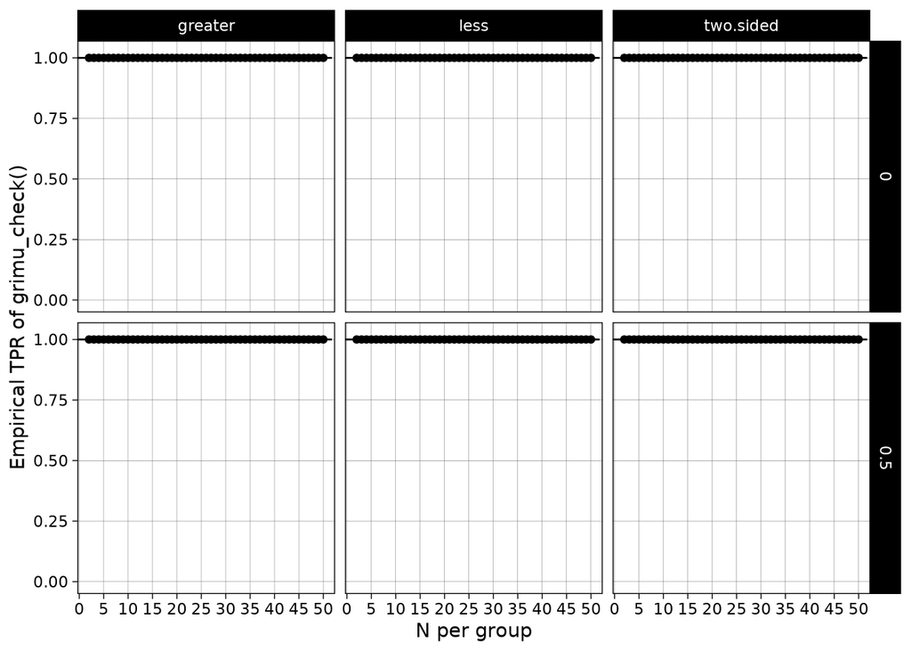

```r
ggplot(simulation_summary_by_cell,
       aes(x = pop_n_per_group,
           y = empirical_tpr)) +
  geom_hline(yintercept = 1, linetype = "dashed") +
  geom_linerange(aes(ymin = empirical_tpr - empirical_tpr_mcse,
                     ymax = empirical_tpr + empirical_tpr_mcse),
                 colour = "black") +
  geom_line() +
  geom_point() +
  facet_grid(as.factor(pop_es) ~ pop_alternative) +
  scale_x_continuous(name = "N per group",
                     breaks = breaks_pretty(n = 8)) +
  scale_y_continuous(name = "Empirical TPR of grimu_check()",
                     limits = c(0, 1.02),
                     breaks = c(0, .25, .5, .75, 1)) +
  theme_linedraw() +
  theme(panel.grid.minor = element_blank()) +
  guides(colour = guide_legend(title = "Population mean difference",
                               reverse = TRUE))
```

## Aim 2 — False positive rate (analytic saturation)

### Significant *p*-values only ($p \in [0, 0.05]$)

#### Reported to 2 decimal places

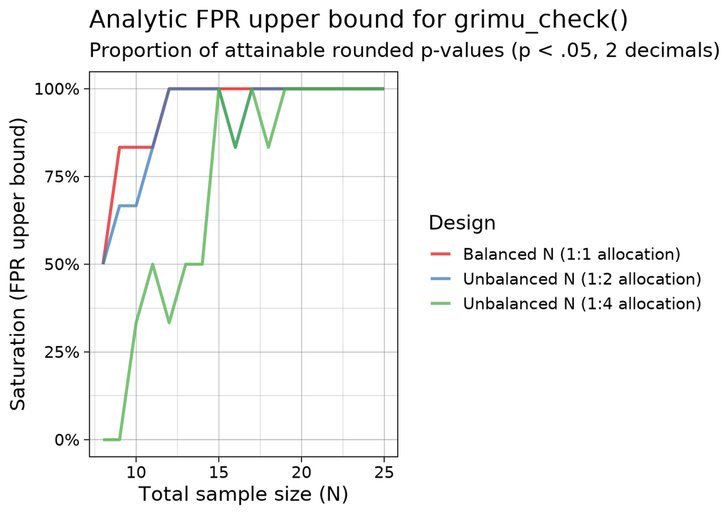

```r
comparison_grid_d2 <- expand_grid(
  n_total = seq(8, 25, by = 1)
) |>
  mutate(
    n1_bal           = floor(n_total * 0.5),
    n2_bal           = ceiling(n_total * 0.5),
    n1_unbal         = floor(n_total * 0.4),
    n2_unbal         = ceiling(n_total * 0.6),
    n1_unbal_extreme = floor(n_total * 0.2),
    n2_unbal_extreme = ceiling(n_total * 0.8),
    sat_balanced           = map2_dbl(n1_bal, n2_bal,
                                       ~grimu_saturation(.x, .y, decimals = 2,
                                                         p_lower_threshold = 0, p_upper_threshold = 0.05)),
    sat_unbalanced         = map2_dbl(n1_unbal, n2_unbal,
                                       ~grimu_saturation(.x, .y, decimals = 2,
                                                         p_lower_threshold = 0, p_upper_threshold = 0.05)),
    sat_unbalanced_extreme = map2_dbl(n1_unbal_extreme, n2_unbal_extreme,
                                       ~grimu_saturation(.x, .y, decimals = 2,
                                                         p_lower_threshold = 0, p_upper_threshold = 0.05))
  )

comparison_grid_d2 |>
  pivot_longer(cols = starts_with("sat_"), names_to = "Design", values_to = "Saturation") |>
  mutate(Design = recode(Design,
                         "sat_balanced"           = "Balanced N (1:1 allocation)",
                         "sat_unbalanced"         = "Unbalanced N (1:2 allocation)",
                         "sat_unbalanced_extreme" = "Unbalanced N (1:4 allocation)")) |>
  ggplot(aes(x = n_total, y = Saturation, colour = Design)) +
  geom_line(linewidth = 1, alpha = 0.75) +
  scale_y_continuous(labels = scales::percent) +
  scale_colour_brewer(palette = "Set1") +
  labs(
    title = "Analytic FPR upper bound for grimu_check()",
    subtitle = "Proportion of attainable rounded p-values (p < .05, 2 decimals)",
    x = "Total sample size (N)",
    y = "Saturation (FPR upper bound)"
  ) +
  theme_linedraw(base_size = 14)
```

#### Reported to 3 decimal places

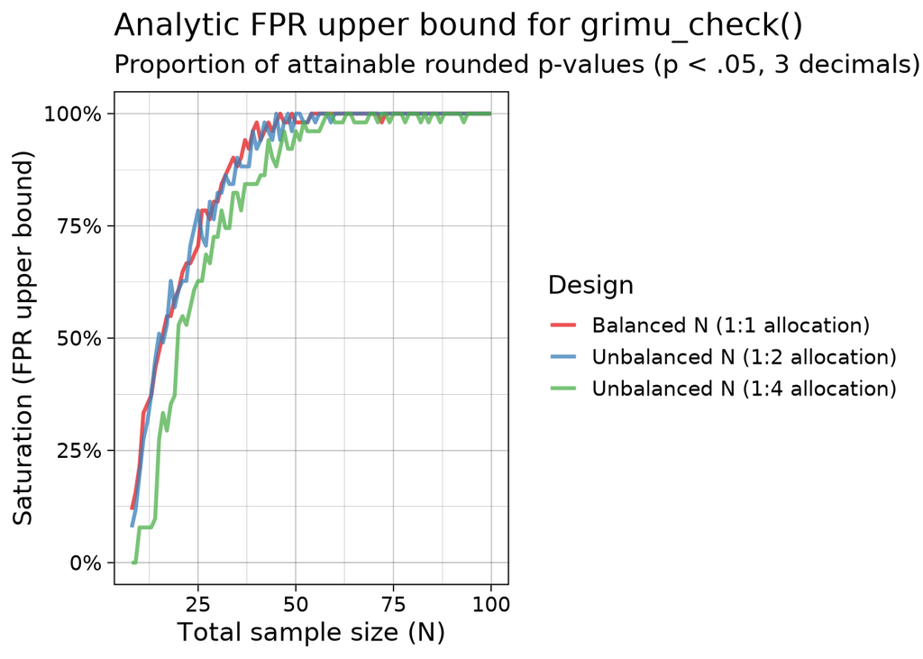

```r
comparison_grid_d3 <- expand_grid(
  n_total = seq(8, 100, by = 1)
) |>
  mutate(
    n1_bal           = floor(n_total * 0.5),
    n2_bal           = ceiling(n_total * 0.5),
    n1_unbal         = floor(n_total * 0.4),
    n2_unbal         = ceiling(n_total * 0.6),
    n1_unbal_extreme = floor(n_total * 0.2),
    n2_unbal_extreme = ceiling(n_total * 0.8),
    sat_balanced           = map2_dbl(n1_bal, n2_bal,
                                       ~grimu_saturation(.x, .y, decimals = 3,
                                                         p_lower_threshold = 0, p_upper_threshold = 0.05)),
    sat_unbalanced         = map2_dbl(n1_unbal, n2_unbal,
                                       ~grimu_saturation(.x, .y, decimals = 3,
                                                         p_lower_threshold = 0, p_upper_threshold = 0.05)),
    sat_unbalanced_extreme = map2_dbl(n1_unbal_extreme, n2_unbal_extreme,
                                       ~grimu_saturation(.x, .y, decimals = 3,
                                                         p_lower_threshold = 0, p_upper_threshold = 0.05))
  )

comparison_grid_d3 |>
  pivot_longer(cols = starts_with("sat_"), names_to = "Design", values_to = "Saturation") |>
  mutate(Design = recode(Design,
                         "sat_balanced"           = "Balanced N (1:1 allocation)",
                         "sat_unbalanced"         = "Unbalanced N (1:2 allocation)",
                         "sat_unbalanced_extreme" = "Unbalanced N (1:4 allocation)")) |>
  ggplot(aes(x = n_total, y = Saturation, colour = Design)) +
  geom_line(linewidth = 1, alpha = 0.75) +
  scale_y_continuous(labels = scales::percent) +
  scale_colour_brewer(palette = "Set1") +
  labs(
    title = "Analytic FPR upper bound for grimu_check()",
    subtitle = "Proportion of attainable rounded p-values (p < .05, 3 decimals)",
    x = "Total sample size (N)",
    y = "Saturation (FPR upper bound)"
  ) +
  theme_linedraw(base_size = 14)
```

#### Reported to 4 decimal places

Excluded from the rendered document because of long compute time; the code below can be uncommented and rerun.

```r
# comparison_grid_d4 <- expand_grid(
#   n_total = seq(8, 250, by = 1)
# ) |>
#   mutate(
#     n1_bal           = floor(n_total * 0.5),
#     n2_bal           = ceiling(n_total * 0.5),
#     n1_unbal         = floor(n_total * 0.4),
#     n2_unbal         = ceiling(n_total * 0.6),
#     n1_unbal_extreme = floor(n_total * 0.2),
#     n2_unbal_extreme = ceiling(n_total * 0.8),
#     sat_balanced           = map2_dbl(n1_bal, n2_bal,
#                                        ~grimu_saturation(.x, .y, decimals = 4,
#                                                          p_lower_threshold = 0, p_upper_threshold = 0.05)),
#     sat_unbalanced         = map2_dbl(n1_unbal, n2_unbal,
#                                        ~grimu_saturation(.x, .y, decimals = 4,
#                                                          p_lower_threshold = 0, p_upper_threshold = 0.05)),
#     sat_unbalanced_extreme = map2_dbl(n1_unbal_extreme, n2_unbal_extreme,
#                                        ~grimu_saturation(.x, .y, decimals = 4,
#                                                          p_lower_threshold = 0, p_upper_threshold = 0.05))
#   )
#
# comparison_grid_d4 |>
#   pivot_longer(cols = starts_with("sat_"), names_to = "Design", values_to = "Saturation") |>
#   mutate(Design = recode(Design,
#                          "sat_balanced"           = "Balanced N (1:1 allocation)",
#                          "sat_unbalanced"         = "Unbalanced N (1:2 allocation)",
#                          "sat_unbalanced_extreme" = "Unbalanced N (1:4 allocation)")) |>
#   ggplot(aes(x = n_total, y = Saturation, colour = Design)) +
#   geom_line(linewidth = 1, alpha = 0.75) +
#   scale_y_continuous(labels = scales::percent) +
#   scale_colour_brewer(palette = "Set1") +
#   labs(
#     title = "Analytic FPR upper bound for grimu_check()",
#     subtitle = "Proportion of attainable rounded p-values (p < .05, 4 decimals)",
#     x = "Total sample size (N)",
#     y = "Saturation (FPR upper bound)"
#   ) +
#   theme_linedraw(base_size = 14)
```

### Full *p*-value range ($p \in [0, 1]$)

#### Reported to 2 decimal places

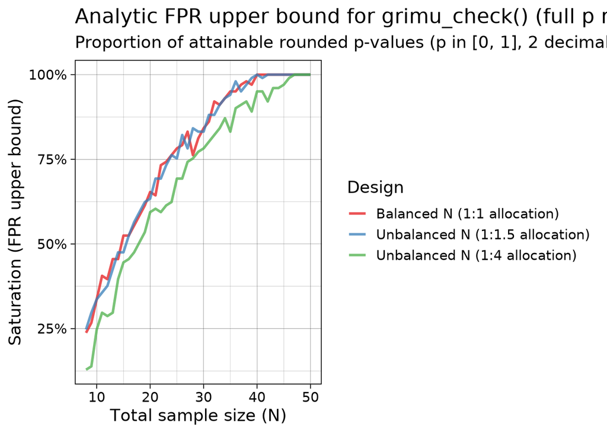

```r
comparison_grid_d2_full <- expand_grid(
  n_total = seq(8, 50, by = 1)
) |>
  mutate(
    n1_bal           = floor(n_total * 0.5),
    n2_bal           = ceiling(n_total * 0.5),
    n1_unbal         = floor(n_total * 0.4),
    n2_unbal         = ceiling(n_total * 0.6),
    n1_unbal_extreme = floor(n_total * 0.2),
    n2_unbal_extreme = ceiling(n_total * 0.8),
    sat_balanced           = map2_dbl(n1_bal, n2_bal,
                                       ~grimu_saturation(.x, .y, decimals = 2,
                                                         p_lower_threshold = 0, p_upper_threshold = 1)),
    sat_unbalanced         = map2_dbl(n1_unbal, n2_unbal,
                                       ~grimu_saturation(.x, .y, decimals = 2,
                                                         p_lower_threshold = 0, p_upper_threshold = 1)),
    sat_unbalanced_extreme = map2_dbl(n1_unbal_extreme, n2_unbal_extreme,
                                       ~grimu_saturation(.x, .y, decimals = 2,
                                                         p_lower_threshold = 0, p_upper_threshold = 1))
  )

comparison_grid_d2_full |>
  pivot_longer(cols = starts_with("sat_"), names_to = "Design", values_to = "Saturation") |>
  mutate(Design = recode(Design,
                         "sat_balanced"           = "Balanced N (1:1 allocation)",
                         "sat_unbalanced"         = "Unbalanced N (1:1.5 allocation)",
                         "sat_unbalanced_extreme" = "Unbalanced N (1:4 allocation)")) |>
  ggplot(aes(x = n_total, y = Saturation, colour = Design)) +
  geom_line(linewidth = 1, alpha = 0.75) +
  scale_y_continuous(labels = scales::percent) +
  scale_colour_brewer(palette = "Set1") +
  labs(
    title = "Analytic FPR upper bound for grimu_check() (full p range)",
    subtitle = "Proportion of attainable rounded p-values (p in [0, 1], 2 decimals)",
    x = "Total sample size (N)",
    y = "Saturation (FPR upper bound)"
  ) +
  theme_linedraw(base_size = 14)
```

#### Reported to 3 decimal places

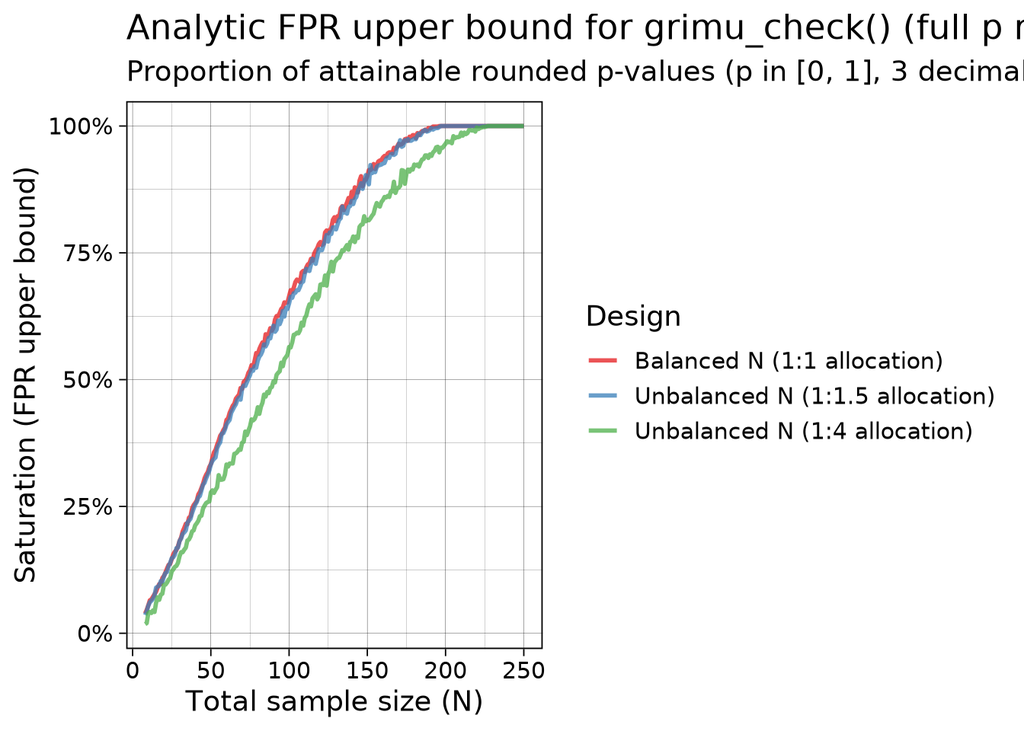

```r
comparison_grid_d3_full <- expand_grid(
  n_total = seq(8, 250, by = 1)
) |>
  mutate(
    n1_bal           = floor(n_total * 0.5),
    n2_bal           = ceiling(n_total * 0.5),
    n1_unbal         = floor(n_total * 0.4),
    n2_unbal         = ceiling(n_total * 0.6),
    n1_unbal_extreme = floor(n_total * 0.2),
    n2_unbal_extreme = ceiling(n_total * 0.8),
    sat_balanced           = map2_dbl(n1_bal, n2_bal,
                                       ~grimu_saturation(.x, .y, decimals = 3,
                                                         p_lower_threshold = 0, p_upper_threshold = 1)),
    sat_unbalanced         = map2_dbl(n1_unbal, n2_unbal,
                                       ~grimu_saturation(.x, .y, decimals = 3,
                                                         p_lower_threshold = 0, p_upper_threshold = 1)),
    sat_unbalanced_extreme = map2_dbl(n1_unbal_extreme, n2_unbal_extreme,
                                       ~grimu_saturation(.x, .y, decimals = 3,
                                                         p_lower_threshold = 0, p_upper_threshold = 1))
  )

comparison_grid_d3_full |>
  pivot_longer(cols = starts_with("sat_"), names_to = "Design", values_to = "Saturation") |>
  mutate(Design = recode(Design,
                         "sat_balanced"           = "Balanced N (1:1 allocation)",
                         "sat_unbalanced"         = "Unbalanced N (1:1.5 allocation)",
                         "sat_unbalanced_extreme" = "Unbalanced N (1:4 allocation)")) |>
  ggplot(aes(x = n_total, y = Saturation, colour = Design)) +
  geom_line(linewidth = 1, alpha = 0.75) +
  scale_y_continuous(labels = scales::percent) +
  scale_colour_brewer(palette = "Set1") +
  labs(
    title = "Analytic FPR upper bound for grimu_check() (full p range)",
    subtitle = "Proportion of attainable rounded p-values (p in [0, 1], 3 decimals)",
    x = "Total sample size (N)",
    y = "Saturation (FPR upper bound)"
  ) +
  theme_linedraw(base_size = 14)
```

#### Reported to 4 decimal places

Excluded from the rendered document because of long compute time; the code below can be uncommented and rerun.

```r
# comparison_grid_d4_full <- expand_grid(
#   n_total = seq(8, 500, by = 1)
# ) |>
#   mutate(
#     n1_bal           = floor(n_total * 0.5),
#     n2_bal           = ceiling(n_total * 0.5),
#     n1_unbal         = floor(n_total * 0.4),
#     n2_unbal         = ceiling(n_total * 0.6),
#     n1_unbal_extreme = floor(n_total * 0.2),
#     n2_unbal_extreme = ceiling(n_total * 0.8),
#     sat_balanced           = map2_dbl(n1_bal, n2_bal,
#                                        ~grimu_saturation(.x, .y, decimals = 4,
#                                                          p_lower_threshold = 0, p_upper_threshold = 1)),
#     sat_unbalanced         = map2_dbl(n1_unbal, n2_unbal,
#                                        ~grimu_saturation(.x, .y, decimals = 4,
#                                                          p_lower_threshold = 0, p_upper_threshold = 1)),
#     sat_unbalanced_extreme = map2_dbl(n1_unbal_extreme, n2_unbal_extreme,
#                                        ~grimu_saturation(.x, .y, decimals = 4,
#                                                          p_lower_threshold = 0, p_upper_threshold = 1))
#   )
```

# Discussion

## Conclusions with regard to the aims

1. **Aim 1 met.** `grimu_check()` returns `consistent = TRUE` for the overwhelming majority of (and likely all non-edge-case) simulated reports produced by a real `wilcox.test()`. The TPR is indistinguishable from 1 at the Monte Carlo resolution used here.
2. **Aim 2 characterised.** The analytic FPR upper bound is governed by the *U* distribution’s saturation. The practical implication is that GRIM-U is at its most forensically useful in (a) small samples, (b) high-precision *p*-value reports (≥ 3 decimal places), and (c) unbalanced designs.

## Limitations and intended use

- **One method only.** No comparator (e.g. Heathers-style ANOVA-bounds checks, or Grimes’s original Monte Carlo prototype) is included; the simulation cannot be used to argue for `grimu_check()` over alternatives on grounds of relative performance, only to characterise its absolute operating characteristics.
- **One reporting precision in Aim 1.** TPR is evaluated only at `digits = 3`, which is the modal reporting precision in published *U*-tests but not the only one. Replicating Aim 1 at `digits = 2` and `digits = 4` is straightforward and is left to future work.
- **Best-case Aim 2 fabricator.** The saturation upper bound assumes a fabricator who samples uniformly from $[p_\ell, p_u]$. A realistic fabricator targeting publishable values (e.g. just below 0.05) would face a smaller effective range, and the realised FPR could be larger than the saturation estimate. Conversely, fabricators reporting at higher precision than the *U*-test naturally produces would face a smaller realised FPR.

Used as intended — as a hypothesis-testing-style validation simulation alongside the package’s unit tests — this study provides converging evidence that `grimu_check()` is calibrated against its own design specification, and quantifies the range of designs in which it is informative.

# References

Brown, N. J. L., & Heathers, J. A. J. (2017). The GRIM test: A simple technique detects numerous anomalies in the reporting of results in psychology. *Social Psychological and Personality Science*, 8(4), 363–369. https://doi.org/10.1177/1948550616673876

Cohen, J. (1988). *Statistical power analysis for the behavioral sciences* (2nd ed.). Lawrence Erlbaum Associates.

Grimes, D. (2024). *GRIM-U: a forensic consistency check for reported Mann–Whitney U tests* [Working code release].

Heathers, J. A. J., Anaya, J., van der Zee, T., & Brown, N. J. L. (2018). Recovering data from summary statistics: Sample Parameter Reconstruction via Iterative TEchniques (SPRITE). *PeerJ Preprints*, 6, e26968v1. https://doi.org/10.7287/peerj.preprints.26968v1

Hussey, I. (2025). *analyticgrimu: Analytic GRIM-U for Mann–Whitney U-test forensic consistency checks* [R package]. https://github.com/ianhussey/analyticgrimu

Morris, T. P., White, I. R., & Crowther, M. J. (2019). Using simulation studies to evaluate statistical methods. *Statistics in Medicine*, 38(11), 2074–2102. https://doi.org/10.1002/sim.8086

Siepe, B. S., Bartoš, F., Morris, T. P., Boulesteix, A.-L., Heck, D. W., & Pawel, S. (2024). Simulation studies for methodological research in psychology: A standardized template for planning, preregistration, and reporting. *Psychological Methods*. https://doi.org/10.1037/met0000695